# Uni

Johannes Piipponen

9 10 2019

# Tämä dokumentti on tehty kokonaan R-ohjelmalla

## Ladataan pari pakettia joilla päästään alkuun ja unidata excelistä

Filtteröidään tyhjät rivit pois, määritetään että aika-sarake on varmasti aikaformaatissa, katsotaan hieman miltä data näyttää.

```r
library(readxl)    #luetaan excel
library(tidyverse) #piiputus, kuvat, kaikki
library(lubridate) #aggrekoidaan vuodet
library(pander)    #siistit taulukot

options(digits = 3)

df=read_excel("loki.xlsx", col_names =TRUE,na="") %>%
  filter(complete.cases(.))  %>%
  mutate(aika=as.Date(aika))

df %>% head() %>% pander()
```

Table continues below

| aika | vknpv | unituntia | unettomuus | myohaan | urheilu | aivotyo |
| --- | --- | --- | --- | --- | --- | --- |
| 2017-12-01 | pe | 7.5 | 0 | 0 | 0 | 1 |
| 2017-12-02 | la | 6 | 1 | 0 | 1 | 1 |
| 2017-12-03 | su | 7.5 | 0 | 0 | 1 | 0 |
| 2017-12-04 | ma | 7 | 0 | 0 | 1 | 0 |
| 2017-12-05 | ti | 7.5 | 0 | 0 | 0 | 0 |
| 2017-12-06 | ke | 6.3 | 1 | 0 | 1 | 0 |

| tukevaruoka | alko | kahvi | ressi | kipea | hyvin | dota | sauna | suihku | kvalo |
| --- | --- | --- | --- | --- | --- | --- | --- | --- | --- |
| 0 | 0 | 0 | 0 | 0 | 1 | 0 | 0 | 0 | 0 |
| 0 | 0 | 0 | 0 | 0 | 1 | 0 | 0 | 0 | 0 |
| 0 | 1 | 0 | 0 | 0 | 1 | 0 | 0 | 0 | 0 |
| 0 | 0 | 0 | 0 | 0 | 1 | 0 | 0 | 0 | 0 |
| 1 | 0 | 0 | 0 | 0 | 1 | 0 | 0 | 0 | 0 |
| 1 | 1 | 0 | 0 | 0 | 1 | 0 | 0 | 0 | 0 |

## Kuvataan data

| muuttuja | selite |
| --- | --- |
| aika | pvm jolloin tapahtumat mitataan |
| vknpv | viikonpaiva |
| unituntia | unen maara tunteina |
| unettomuus | ei unettomuutta=0, selvasti pitka ja turhauttava aika ennen kuin nukahtaa =1, stressiheraaminen aamulla=2 |
| myohaan | ennen klo23 saa arvon 0, 23-00 arvon 1 ja 00–>arvon 2 |
| urheilu | ei urheilua=0, urheilu paivan aikana=1, kova urheilu illalla klo 18 jalkeen=2 |
| aivotyo | ei aivotyota illalla klo 19 jalkeen=0, vaativaa ajattelua klo 19 jalkeen=1 |
| tukevaruoka | ei tuhtia illallista=0, raskas ruoka klo 19 jalkeen |
| alko | ei alkoholia=0, alkoholia enemman kuin siemaus=1 |
| kahvi | ei kahvia=0, kahvi aamulla=1, kahvi klo12 jälkeen 2 |
| ressi | ei stressia=0, selvä stressintuntu seuraavasta päivasta=1 |
| kipea | terve kuin pukki=0, kipea tai selva puolikunto=1 |
| hyvin | riidoissa vaimon kanssa=0, menee hyvin=1 |
| dota | ei dotaa=0,dota 19-21 =1, dota 21 –> =2 |
| sauna | ei saunaa=0, sauna klo 19-21=1, sauna klo 21–>=2 |
| suihku | suihku illalla ennen nukkumaanmenoa |
| kvalo | kirkasvalo tunteina aamulla ennen klo 09:30 |

## Muutetaan kaikki data binaariseksi

Aineistossa siirryttiin jossain välissä 0 1 datasta 0 1 2 dataan. Muutetaan tässä vaiheessa kaikki data 0 1 muotoon siten, että 2 –> 1

## Frekvenssejä

Kahvia juodaan harvoin, mutta juonti lisää selvästi unettomuutta. Kun kahvia juodaan, unettomuuden yleisyys kasvaa kolmenkertaiseksi.

```
##
##    Cell Contents
## |-------------------------|
## |                   Count |
## |             Row Percent |
## |          Column Percent |
## |-------------------------|
##
## Total Observations in Table:  598
##
##                 | df01$kahvi
## df01$unettomuus |        0  |        1  | Row Total |
## ----------------|-----------|-----------|-----------|
##               0 |      468  |       44  |      512  |
##                 |     91.4% |      8.6% |     85.6% |
##                 |     88.0% |     66.7% |           |
## ----------------|-----------|-----------|-----------|
##               1 |       64  |       22  |       86  |
##                 |     74.4% |     25.6% |     14.4% |
##                 |     12.0% |     33.3% |           |
## ----------------|-----------|-----------|-----------|
##    Column Total |      532  |       66  |      598  |
##                 |     89.0% |     11.0% |           |
## ----------------|-----------|-----------|-----------|
##
##
```

## Tutkitaan korrelaatioita

Vahvaa negatiivista korrelaatiota muuttujien unettomuus ja unituntia kanssa. Tämä on toki ilmiselvää, koska herätys on samaan aikaan riippumatta siitä saako illalla nukahdettua vai ei. Toisin sanoen, korrelaatio on niin korkea, että voidaan puhua multikollineaarisuudesta. Negatiivista korrelaatiota myös muuttujien kahvi ja unituntia sekä ressi ja unituntia välillä. Positiivista korrelaatiota muuttujien aivotyö ja ressi, unettomuus ja kahvi sekä kipeä ja unituntia välillä.

Nähdään selvästi, että mikäli jokin muuttuja korreloi negatiivisesti unituntia-muuttujan kanssa, se korreloi positiivisesti muuttujan unettomuus kanssa.

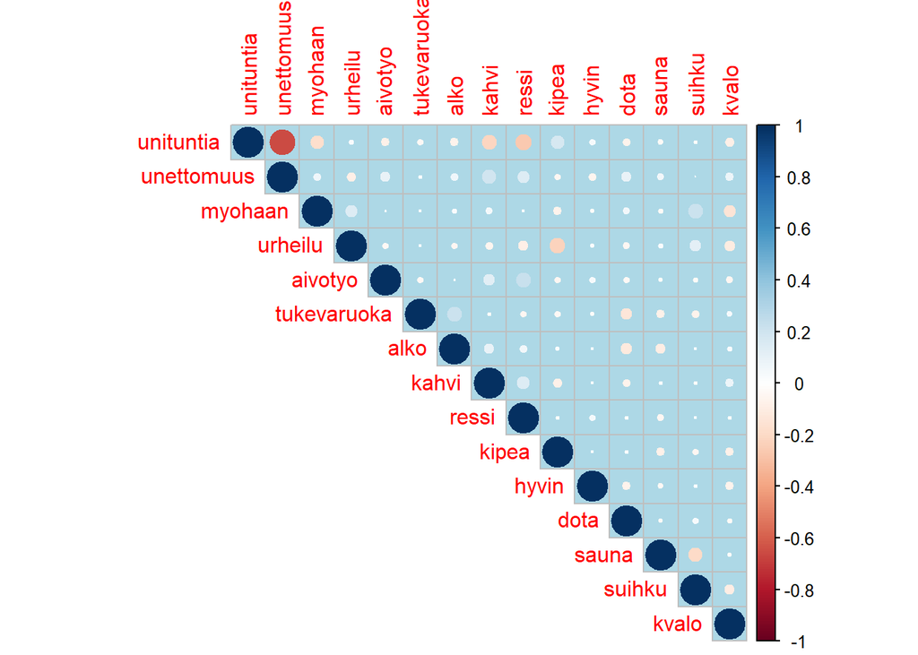

## Test of independence

Tutkitaan onko unituntia-keskiarvo eri luokissa kahvi=0 ja kahvi=1. Huomataan selvä (ja merkitsevä) ero!

Welch Two Sample t-test: `df01$unituntia` by `df01$kahvi` (continued below)

| Test statistic | df | P value | Alternative hypothesis |
| --- | --- | --- | --- |
| 4.044 | 72.54 | 0.0001295 * * * | two.sided |

| mean in group 0 | mean in group 1 |
| --- | --- |
| 7.116 | 6.279 |

## Keskiarvoja

Muuttujana unen määrä tunteina. Havainnot suurimmaksi osaksi välillä 6.6 - 7.8 h. Lauantaina nukkuu yleensä eniten

| 0% | 25% | 50% | 75% | 100% |
| --- | --- | --- | --- | --- |
| 1.2 | 6.525 | 7.2 | 7.8 | 10 |

| ke | la | ma | pe | su | ti | to |
| --- | --- | --- | --- | --- | --- | --- |
| 6.834 | 7.619 | 6.741 | 7.288 | 6.99 | 6.684 | 7.023 |

# Otetaan uusi 012 data talteen (alkaa 2019-01-20)

Valitaan data eteenpäin ajasta 2019-01-20 Sitten 012 data factoreiksi.

## Anova

Käytetään nyt 0 1 2 dataa. Valitaan muuttujat myöhään (ennen klo23 saa arvon 0, 23-00 arvon 1 ja 00–>arvon 2) ja unituntia. Piirretään ensin boxplot-kuviot. Havaintoja eniten ryhmässä myöhään=1. Unimäärä näyttää vähenevän kun nukkumaanmenoaika myöhästyy.

Tehdään varsinainen anova-taulukko Huomataan, että muuttujien välillä on merkittävä riippuvuus, mutta muuta ei vielä tiedetäkään.

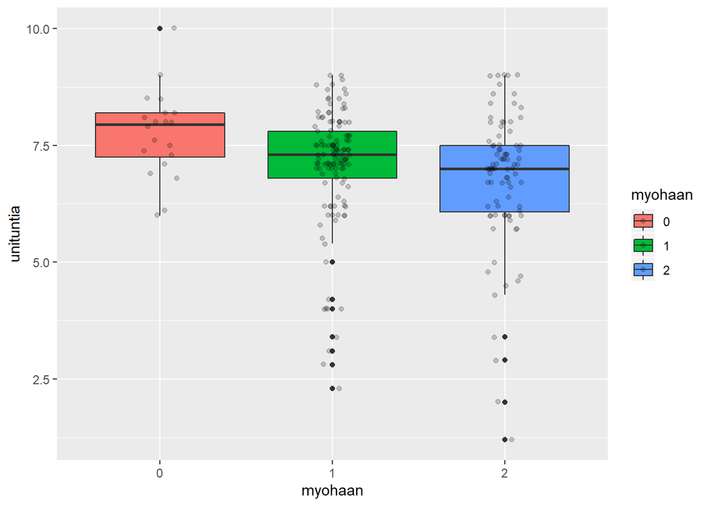

```r
ggplot(df012, aes(x=myohaan, y=unituntia, fill=myohaan))+
  geom_boxplot() + geom_jitter(width=0.1,alpha=0.2)
```

```r
res.aov<-aov(unituntia ~ myohaan, data=df012)
res.aov %>% summary() %>% pander()
```

Analysis of Variance Model

|  | Df | Sum Sq | Mean Sq | F value | Pr(>F) |
| --- | --- | --- | --- | --- | --- |
| **myohaan** | 2 | 15.56 | 7.78 | 4.479 | 0.01236 |
| **Residuals** | 229 | 397.8 | 1.737 | NA | NA |

## Tukey multiple pairwais comparison

Ero ainoastaan ryhmien myohaan=0 ja myohaan on 2 valillä!

```r
#http://www.sthda.com/english/wiki/one-way-anova-test-in-r
TukeyHSD(res.aov) %>% pander()
```

- **myohaan**:

  |  | diff | lwr | upr | p adj |
  | --- | --- | --- | --- | --- |
  | **1-0** | -0.6878 | -1.437 | 0.06138 | 0.07934 |
  | **2-0** | -0.9607 | -1.731 | -0.1905 | 0.01001 |
  | **2-1** | -0.2729 | -0.7062 | 0.1605 | 0.2999 |

```r
# plot(res.aov, 2) #outlierit riveillä 151 13 181
```

## OLS regressio 01 datalla

Myöhään meno vähentää unen määrää. Samoin ressi, kahvi ja valitettavasti dotakin (tietokonepeli).. Kipeänä nukkuu sitä vastoin hyvin!

Mukautettu R^2 ~0.15, eli ei kovin kehuttava. Kokeillaan stepwise proseduuria alempana.

```
##
## Call:
## lm(formula = unituntia ~ myohaan + urheilu + aivotyo + tukevaruoka +
##     alko + kahvi + ressi + kipea + dota + sauna + suihku + hyvin,
##     data = df01)
##
## Residuals:
##    Min     1Q Median     3Q    Max
## -5.681 -0.433  0.085  0.674  2.952
##
## Coefficients:
##             Estimate Std. Error t value Pr(>|t|)
## (Intercept)   7.2213     0.2250   32.10  < 2e-16 ***
## myohaan      -0.4000     0.0995   -4.02  6.5e-05 ***
## urheilu       0.1131     0.0975    1.16     0.25
## aivotyo       0.0294     0.3104    0.09     0.92
## tukevaruoka  -0.2639     0.2129   -1.24     0.22
## alko         -0.1733     0.1772   -0.98     0.33
## kahvi        -0.6187     0.1491   -4.15  3.8e-05 ***
## ressi        -1.6328     0.2696   -6.06  2.5e-09 ***
## kipea         0.7180     0.1807    3.97  7.9e-05 ***
## dota         -0.2038     0.1084   -1.88     0.06 .
## sauna        -0.0958     0.1057   -0.91     0.37
## suihku        0.0373     0.1489    0.25     0.80
## hyvin         0.1959     0.2090    0.94     0.35
## ---
## Signif. codes:  0 '***' 0.001 '**' 0.01 '*' 0.05 '.' 0.1 ' ' 1
##
## Residual standard error: 1.11 on 585 degrees of freedom
## Multiple R-squared:  0.165,  Adjusted R-squared:  0.148
## F-statistic: 9.65 on 12 and 585 DF,  p-value: <2e-16
```

## Tutkitaan edellä tehdyn mallin oletuksia

Residuaalit eivät näytä normaalijakautuneilta (kuvat A-C). Shapiro-Wilk ja muut normaalisuustestit hylkäävät nollahypoteesin. Toisin sanoen, malli ei näytä täyttävän normaalisuusvaatimuksia. Huom! Ainoastaan error termien pitää olla norm jakautuneita, ei muuttujan unituntia!

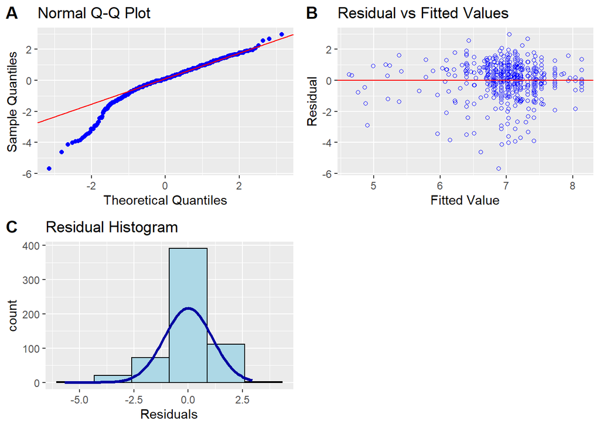

```r
ggarrange(a,b,c,labels = c("A", "B","C" ),  ncol = 2, nrow = 2)
```

```r
ols_test_normality(model)  #Test for detecting violation of normality assumption
```

```
## -----------------------------------------------
##        Test             Statistic       pvalue
## -----------------------------------------------
## Shapiro-Wilk              0.9253         0.0000
## Kolmogorov-Smirnov        0.1043         0.0000
## Cramer-von Mises          35.214         0.0000
## Anderson-Darling          9.7761         0.0000
## -----------------------------------------------
```

```r
#ols_test_breusch_pagan(model)
#samanlaiset kuvat saisi plot(model) komennolla..
#ols_coll_diag(model) #interpretation?
```

## Stepwise regression

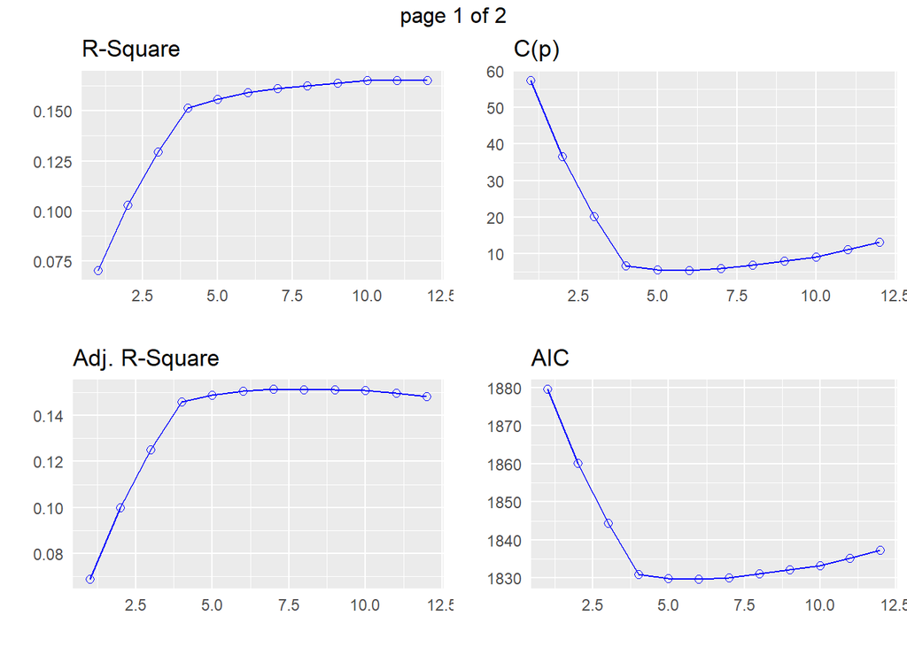

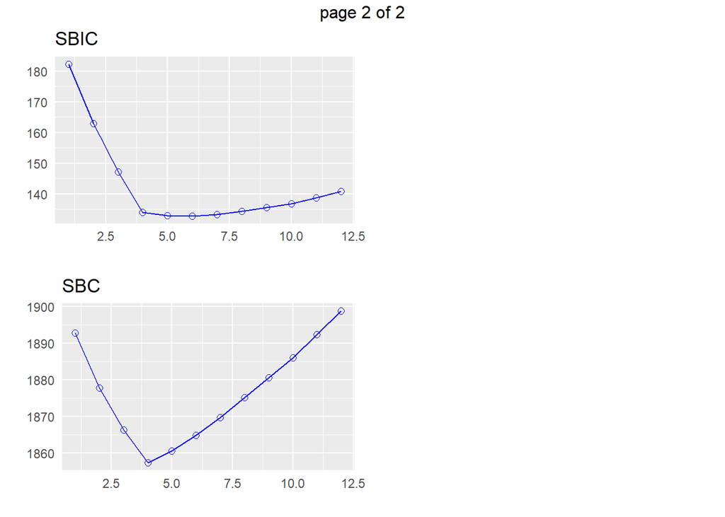

```r
ols_step_best_subset(model) %>% plot()
```

## OLS regressio 012 datalla

Loppuviikosta to-la nukkuu parhaiten. Mitä myöhempään menee nukkumaan, sitä vähemmän unta saa. Huom! Kahvia juotu vain todella huonosti nukuttujen öiden jälkeen –> seuraavana yönä nukkuu vaikka aamulla puoli kuppia joisikin.

```r
lm(unituntia ~vknpv+myohaan+urheilu+aivotyo+tukevaruoka+alko+kahvi+ressi+kipea+dota+sauna, data=df012) %>% summary()
```

```
##
## Call:
## lm(formula = unituntia ~ vknpv + myohaan + urheilu + aivotyo +
##     tukevaruoka + alko + kahvi + ressi + kipea + dota + sauna,
##     data = df012)
##
## Residuals:
##    Min     1Q Median     3Q    Max
## -4.771 -0.416  0.183  0.661  2.434
##
## Coefficients:
##             Estimate Std. Error t value Pr(>|t|)
## (Intercept)   7.5624     0.3596   21.03  < 2e-16 ***
## vknpvla       1.3582     0.3329    4.08  6.4e-05 ***
## vknpvma       0.1495     0.3036    0.49   0.6230
## vknpvpe       0.8497     0.3000    2.83   0.0051 **
## vknpvsu       0.4259     0.3064    1.39   0.1659
## vknpvti       0.1559     0.3058    0.51   0.6108
## vknpvto       0.7211     0.3098    2.33   0.0209 *
## myohaan1     -0.7656     0.2952   -2.59   0.0102 *
## myohaan2     -1.3327     0.3102   -4.30  2.7e-05 ***
## urheilu1      0.2591     0.1948    1.33   0.1848
## urheilu2     -0.0203     0.2493   -0.08   0.9351
## aivotyo       0.6610     0.6379    1.04   0.3012
## tukevaruoka  -0.3731     0.4759   -0.78   0.4340
## alko         -0.7243     0.3496   -2.07   0.0395 *
## kahvi        -0.5068     0.2571   -1.97   0.0500 .
## ressi        -1.6959     0.5187   -3.27   0.0013 **
## kipea         0.6813     0.3929    1.73   0.0844 .
## dota1         0.1370     0.3221    0.43   0.6711
## dota2        -0.3089     0.2278   -1.36   0.1766
## sauna1        0.0449     0.3181    0.14   0.8878
## sauna2       -0.3371     0.2260   -1.49   0.1374
## ---
## Signif. codes:  0 '***' 0.001 '**' 0.01 '*' 0.05 '.' 0.1 ' ' 1
##
## Residual standard error: 1.18 on 211 degrees of freedom
## Multiple R-squared:  0.289,  Adjusted R-squared:  0.221
## F-statistic: 4.28 on 20 and 211 DF,  p-value: 2.87e-08
```

```r
lm(unituntia ~myohaan+urheilu+alko+kahvi+ressi+kipea+dota+sauna+hyvin, data=df012) %>% summary()
```

```
##
## Call:
## lm(formula = unituntia ~ myohaan + urheilu + alko + kahvi + ressi +
##     kipea + dota + sauna + hyvin, data = df012)
##
## Residuals:
##    Min     1Q Median     3Q    Max
## -4.897 -0.516  0.090  0.739  2.336
##
## Coefficients:
##             Estimate Std. Error t value Pr(>|t|)
## (Intercept)   7.2650     0.3654   19.88  < 2e-16 ***
## myohaan1     -0.8842     0.3005   -2.94  0.00361 **
## myohaan2     -1.2460     0.3136   -3.97  9.6e-05 ***
## urheilu1      0.3531     0.1884    1.87  0.06223 .
## urheilu2     -0.2287     0.2396   -0.95  0.34089
## alko         -0.8046     0.3328   -2.42  0.01646 *
## kahvi        -0.5995     0.2465   -2.43  0.01581 *
## ressi        -1.9597     0.5237   -3.74  0.00023 ***
## kipea         0.8390     0.3919    2.14  0.03341 *
## dota1         0.0946     0.3217    0.29  0.76904
## dota2        -0.3445     0.2251   -1.53  0.12735
## sauna1        0.3244     0.3130    1.04  0.30106
## sauna2       -0.0774     0.2158   -0.36  0.72002
## hyvin         0.8823     0.2763    3.19  0.00162 **
## ---
## Signif. codes:  0 '***' 0.001 '**' 0.01 '*' 0.05 '.' 0.1 ' ' 1
##
## Residual standard error: 1.2 on 218 degrees of freedom
## Multiple R-squared:  0.236,  Adjusted R-squared:  0.191
## F-statistic: 5.19 on 13 and 218 DF,  p-value: 4.84e-08
```

# Logistinen regressio 01 datalla

```r
library(ISLR) #kannattais kokeilla pakettia  blorr
malli_glm01 <- glm(unettomuus~myohaan+urheilu+aivotyo+tukevaruoka+alko+kahvi+ressi+kipea+dota+sauna, family=binomial(link="logit"),data=df01)
malli_glm01 %>% summary()
```

```
##
## Call:
## glm(formula = unettomuus ~ myohaan + urheilu + aivotyo + tukevaruoka +
##     alko + kahvi + ressi + kipea + dota + sauna, family = binomial(link = "logit"),
##     data = df01)
##
## Deviance Residuals:
##    Min      1Q  Median      3Q     Max
## -1.423  -0.559  -0.468  -0.387   2.292
##
## Coefficients:
##             Estimate Std. Error z value Pr(>|z|)
## (Intercept)   -2.482      0.293   -8.46  < 2e-16 ***
## myohaan        0.371      0.274    1.36  0.17535
## urheilu       -0.442      0.267   -1.65  0.09801 .
## aivotyo        0.729      0.650    1.12  0.26232
## tukevaruoka    0.373      0.549    0.68  0.49741
## alko           0.451      0.428    1.05  0.29201
## kahvi          1.116      0.317    3.52  0.00042 ***
## ressi          1.105      0.541    2.04  0.04102 *
## kipea         -0.425      0.557   -0.76  0.44577
## dota           0.705      0.271    2.61  0.00918 **
## sauna          0.395      0.266    1.48  0.13787
## ---
## Signif. codes:  0 '***' 0.001 '**' 0.01 '*' 0.05 '.' 0.1 ' ' 1
##
## (Dispersion parameter for binomial family taken to be 1)
##
##     Null deviance: 492.54  on 597  degrees of freedom
## Residual deviance: 453.27  on 587  degrees of freedom
## AIC: 475.3
##
## Number of Fisher Scoring iterations: 5
```

```r
exp(malli_glm01$coefficients)
```

```
## (Intercept)     myohaan     urheilu     aivotyo tukevaruoka        alko
##      0.0836      1.4495      0.6427      2.0728      1.4515      1.5701
##       kahvi       ressi       kipea        dota       sauna
##      3.0536      3.0190      0.6540      2.0248      1.4846
```

# Piirretään kuvioita

Unen määrä tunteina

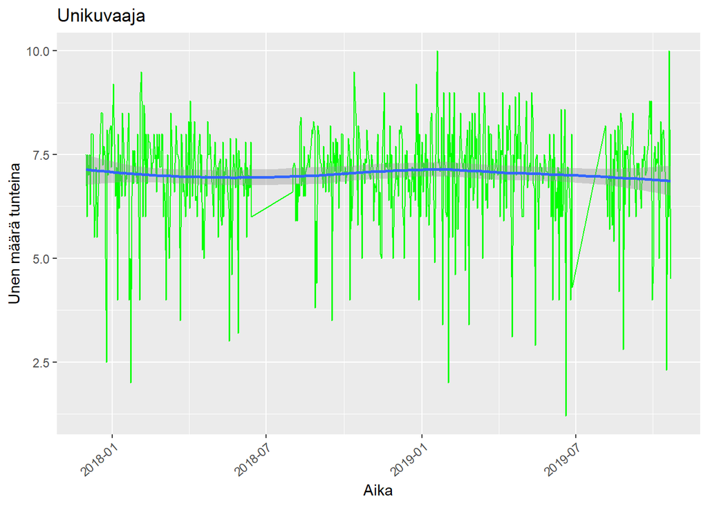